# Proposed Research on Toothfish (Dissostichus spp.)

## CCAMLR Conservation Measure 24-01, Paragraph 3

### Chilean Research Plan for Subareas 48.2 and 48.3A

## Overview of Research Plans

- **Two separate but complementary research proposals:**
  - Subarea 48.2 (Northern and Southern Research Blocks)
  - Subarea 48.3A
- **Duration:** Three fishing seasons (2025/26 - 2027/28)
- **Research vessel:** FV GlobalPesca I
- **Primary focus:** Patagonian toothfish (D. eleginoides) and Antarctic toothfish (D. mawsoni)

## Key Research Rationale

**Significant data gaps exist in both areas:**

- No data collected in Subarea 48.2 since 2019
- No data collected in Subarea 48.3A since 2005

**Current understanding limited by:**

- Lack of standardized research surveys
- Lack of updated biological data
- Need for relative abundance estimates

**Research supports CCAMLR’s conservation objectives**

**Strategic importance for Chile:**

- Establish meaningful presence in CCAMLR fishing research
- Contribute to sustainable management of Antarctic marine resources
- Build scientific expertise and capacity in Antarctic marine resources
- Strengthen Chile’s position as a responsible fishing nation in Antarctic waters

## Research Objectives

**For both research areas:**

- Obtain relative abundance estimates for toothfish by depth strata
- Characterize size and age structure and mean length of toothfish
- Characterize reproductive/maturity indices and species ratios
- Continue the CCAMLR Toothfish Tagging and Recapture Program
- Characterize bycatch species
- Document interactions of seabirds and marine mammals with fishing operations

## Research Location: Subarea 48.2

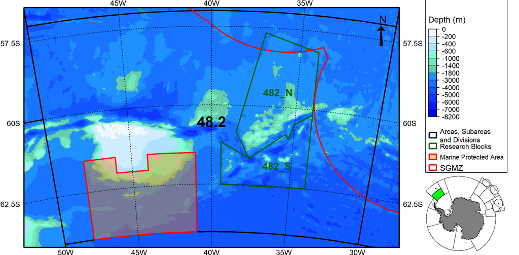

#### **Map of Subarea 48.2**

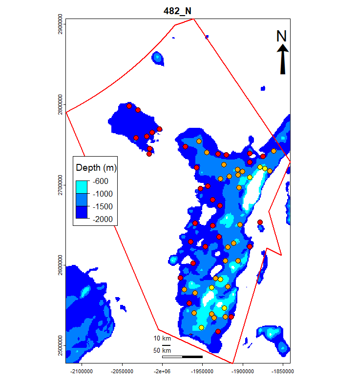

#### **Map of Subarea 48.2N**

- *Note: South Georgia Maritime Zone (SGMZ) excluded from survey area 48.2N*

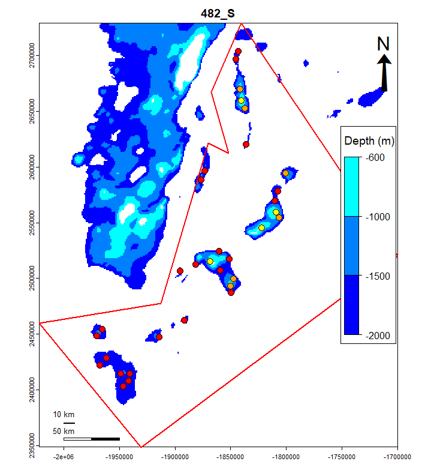

#### **Map of Subarea 48.2S**

**Northern Research Block (NRB)** and **Southern Research Block (SRB)**

- Total of **98 stations** across both blocks (**64** in NRB, **34** in SRB)
- Stratified random sampling across three depth strata (600-1000m, 1000-1500m, 1500-2000m)

## Research Location: Subarea 48.3A

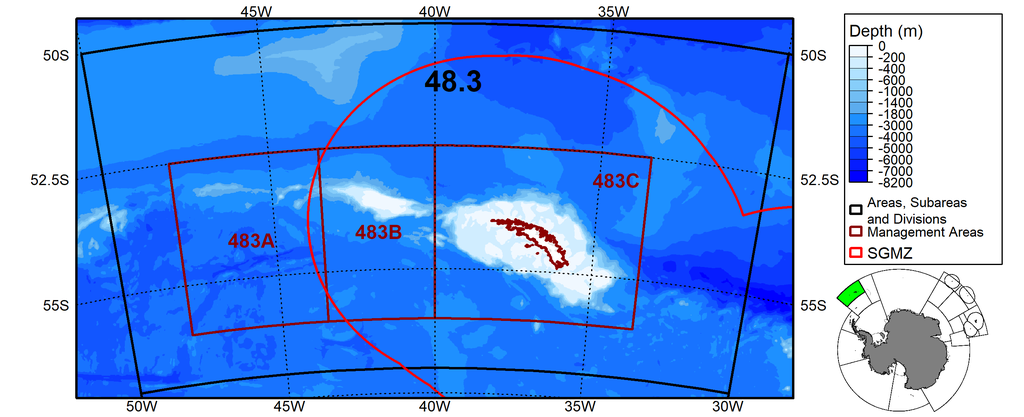

#### **Map of Subarea 48.3A**

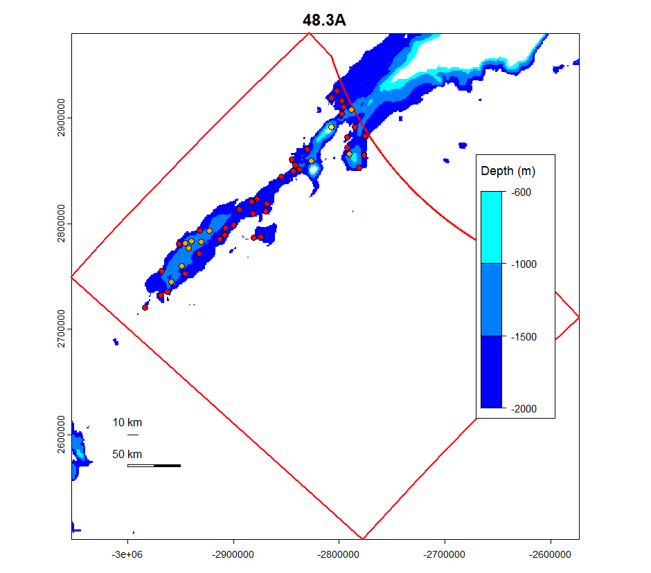

#### **Map of Subarea 48.3A**

**Management Area 48.3A** (western portion of Subarea 48.3)

- Total of **48 stations** throughout the area
- Stratified random sampling across three depth strata (600-1000m, 1000-1500m, 1500-2000m)
- *Note: South Georgia Maritime Zone (SGMZ) excluded from survey area 48.3A*

## Survey Design

**Standardized approach for both areas:**

- **Stratified random sampling (StRS)** with proportional allocation
- Three depth strata: 600-1000m, 1000-1500m, 1500-2000m
- Two-stage cluster sampling for biological data
- Consistent gear configuration (trotline, 2,500 hooks per set)
- Statistical rigor: Coefficient of Variation (CV) of 12% (or precision target of ±300 kg/2500 hooks at 95% confidence)

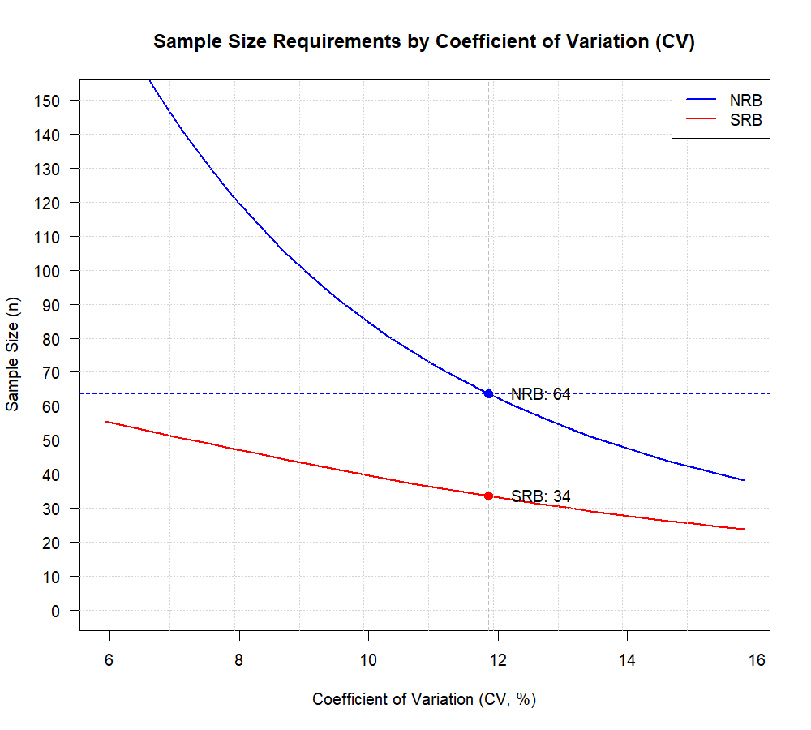

#### **Subarea 48.2**

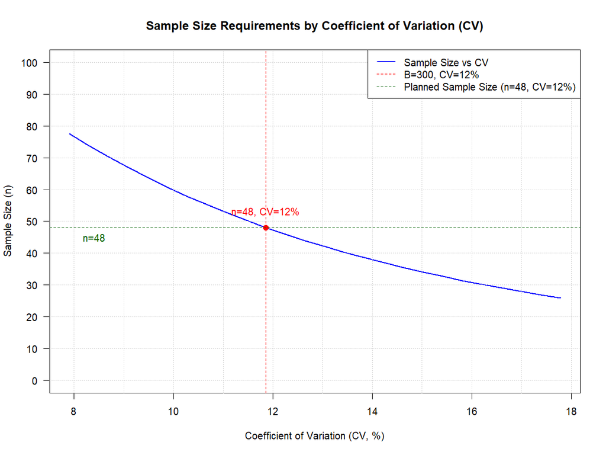

#### **Subarea 48.3A**

## Survey Timing and Duration

**Subarea 48.2:**

- Fishing season: no restrictions
- Survey period: March 1 - May 20 (each season)
- Duration: 81 fishing days (including Weather/maintenance delays)
  - 64 stations in NRB (~43 days)
  - 34 stations in SRB (~22 days)
  - ~1.5 stations per day

**Subarea 48.3A:**

- Fishing season: from 16 April to 14 September
- Survey period: from May 26 - July 5
- Duration: 40 fishing days (including Weather/maintenance delays)
- 48 stations
- ~1.5 stations per day

[figure not shown]

#### Scenarios considering fast or slow operations, with or without buffer

## Proposed Catch Limits

**Subarea 48.2:**

- Total: **188 tonnes**
  - 123 tonnes allocated to NRB (65.3%)
  - 65 tonnes allocated to SRB (34.7%)
- Based on historical CPUE with 50% recovery estimate since 2019
- **Note**: 75 tonnes for each research block (150 tonnes total) CCAMLR’s trend analysis (2023)

**Subarea 48.3A:**

- Total: **76 tonnes**
- Based on historical CPUE with moderate (50%) recovery assumption
- Includes 25% precautionary buffer
- **Note**: No catch limit since 2006 (catch limit was 10 tonnes in 2005)
- **Note**: Catch limits for adjacent areas were 698 tonnes (48.3B) and 1,629 tonnes (48.3C)

## Biological Data Collection

**For both research areas:**

- Minimum 13 fish measured per longline (Type II samples; e.g., length measurements)
- Minimum 5 fish measured per longline (Type III samples; eg., otoliths)
- Sampling intensity of 7 fish per 1,000 hooks
- Sampling intensity based on protocols from CCAMLR
- Full bycatch documentation and VME monitoring
- Seabird and marine mammal observations

**Comprehensive biological sampling program:**

**Subarea 48.2:**

- Expected Type II samples: 1,274 toothfish
- Expected Type III samples: 490 otoliths
- Expected total samples: 1,764
- Expected Type II samples: 980 Macrourus spp
- Tagging program: 5 fish per tonne (48.2)

**Subarea 48.3A:**

- Expected Type II samples: 624 toothfish
- Expected Type III samples: 240 otoliths
- Expected total samples: 864
- Expected Type II samples: 480 Macrourus spp
- Tagging program: 1.3 fish per tonne (48.3A)

## Research Timeline

**For both research areas:**

- **2025/26 season:** Initial surveys (pilot phase)
- **2026/27 season:** Continued surveys with methodology refinements
- **2027/28 season:** Final surveys and comprehensive data collection
- **2029:** Final synthesis report and management recommendations

**Regular reporting:**

- Preliminary results to WG-SAM (June each year)
- Comprehensive reports to WG-FSA (September each year)
- Research reviews to SC-CCAMLR (October each year)

## Research Capability

**Vessel and crew:**

- FV GlobalPesca I
- Total crew: 49 members
- **5** scientific observers (including 1 international)
- Space available for 1 international scientist

**Supporting institutions:**

- Instituto de Fomento Pesquero (IFOP)
- Instituto Antartico Chileno

## Expected Research Outcomes

**Scientific contributions:**

- First standardized abundance estimates for both research areas
- Updated biological parameters for toothfish populations
- Documentation of sex ratios across size classes and depths
- Improved understanding of population structure and dynamics
- Enhanced knowledge of VMEs and ecosystem interactions
- Data for future stock assessments and management decisions

## Alignment with CCAMLR Objectives

**Research directly supports CCAMLR’s mission by:**

- Addressing critical data gaps in data-limited fisheries
- Following established CCAMLR protocols for research activities
- Continuing the CCAMLR Tagging and Recapture Program
- Supporting precautionary management approaches
- Facilitating international scientific collaboration
- Minimizing ecosystem impacts through proven mitigation measures

## Conclusion

- Two well-designed research plans addressing significant data gaps
- Standardized methodology for robust, comparable results
- Conservative catch limits to minimize ecosystem impacts
- Complete alignment with CCAMLR conservation objectives
- Results will substantially improve toothfish management knowledge
- Request approval for implementation in 2025/26 fishing season
- Strategic importance for establishing Chile’s presence in CCAMLR research and fisheries

# Bacalao Survey Timeline Summary

## Key Dates and Duration Estimates

[output not shown]